# Case study: Vehicle Sales Analysis Report

Anthony Lu

2024

## Introduction

This report provides an in-depth analysis of vehicle sales data for a California car dealership company. The primary objectives are to identify top-performing vehicle makes, types, and models, and to extract insights that can inform and enhance future vehicle inventory and marketing strategies.

The objective of this analysis is to explore vehicle sales data to understand the characteristics and trends of the market. By identifying the most popular vehicle makes, types, and models, we aim to develop targeted marketing strategies and inform future vehicle inventory.

## Recommended strategies

### 1. Focusing on popular makes and models.

- Promoting Ford’s Fusion, Escape, and F-150 or Nissan’s Altima, Rouge, and Frontier.
- Promoting Nissan’s and BMW’s cars.
- Promoting Ford’s and Chevrolet’s SUV and Trucks.

### 2. Target SUV and car segments

- Since cars and SUVs are the most popular vehicle types, emphasize brands like Nissan and Toyota.

### 3. Leverage less popular vehicle makes and models to be replaced by the popular ones.

- For Cars promote Ford’s Taurus, Fiesta, and Flex or Nissan’s Leaf, Maxima, and Versa Note.
- For SUVs promote Ford’s Expedition, Excursion, and Escape Hybrid or Nissan’s Xterra, Amada, and Rogue Select.

## Visualizations

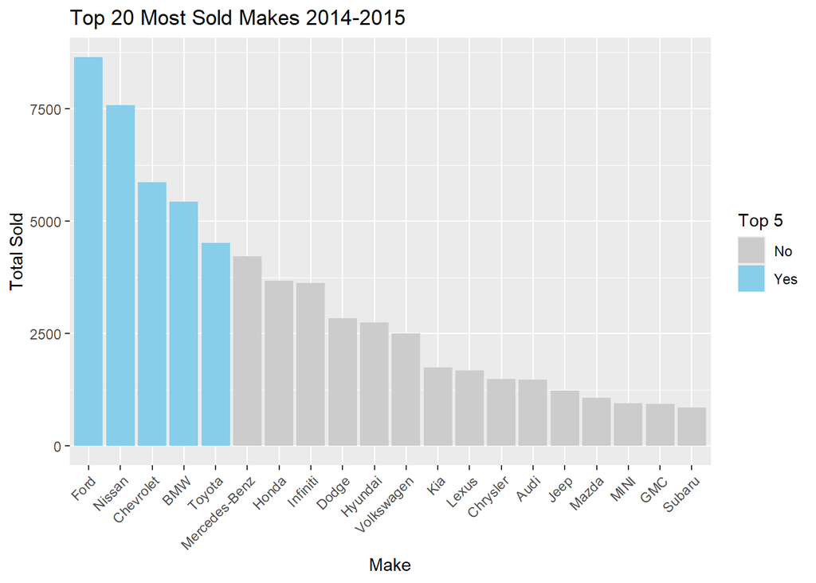

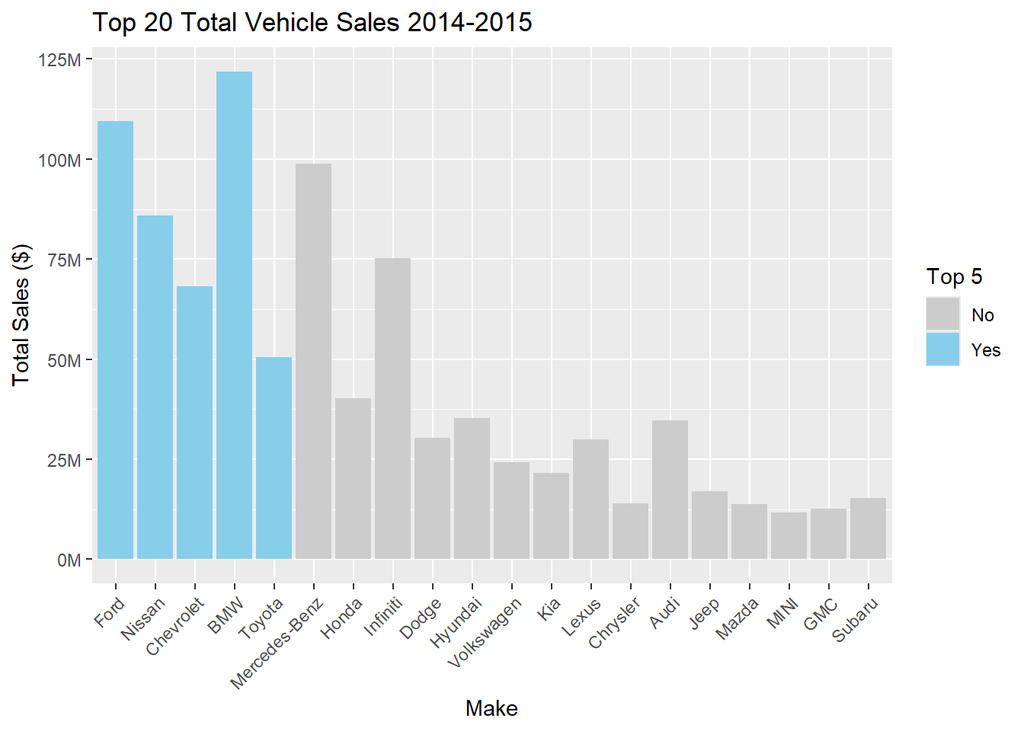

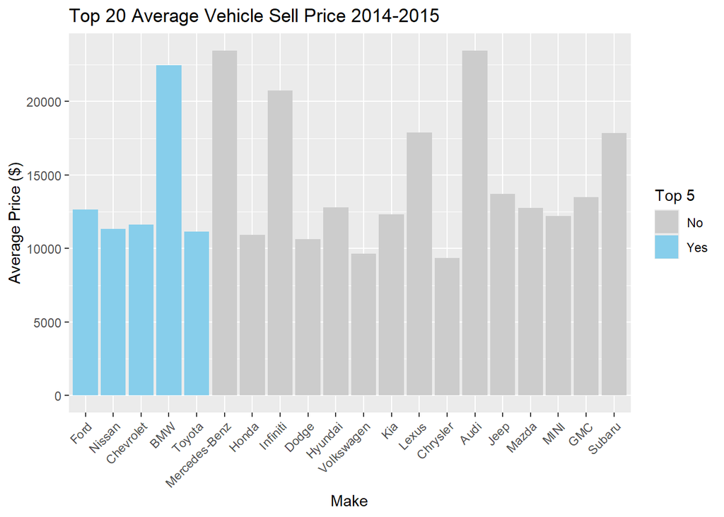

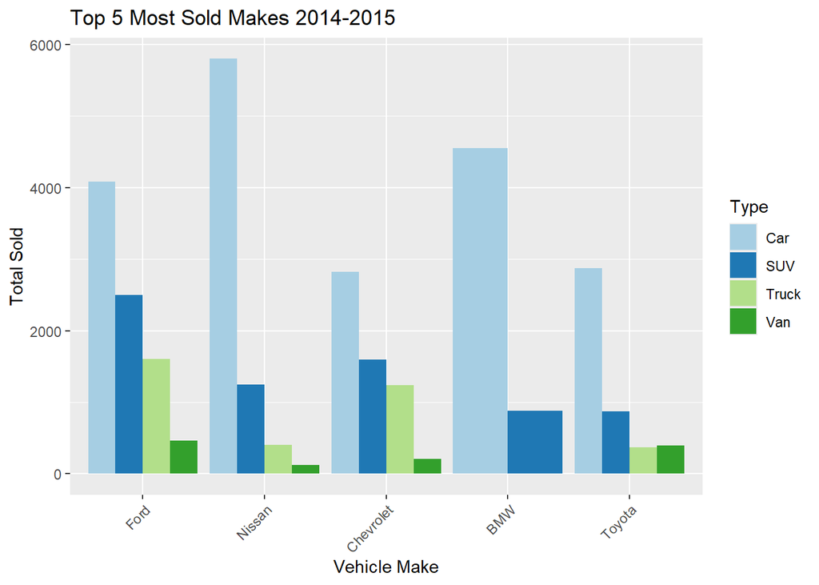

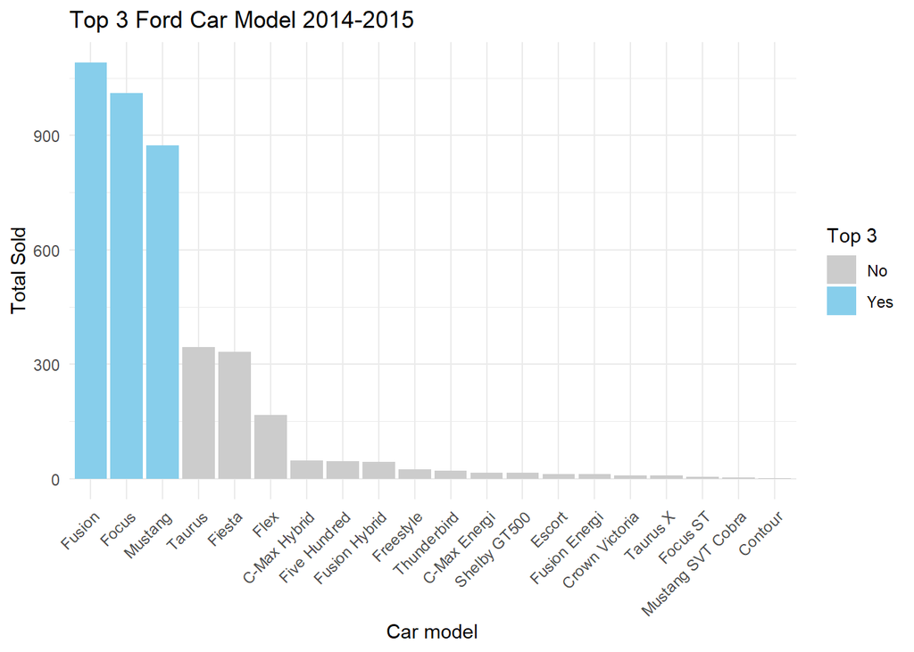

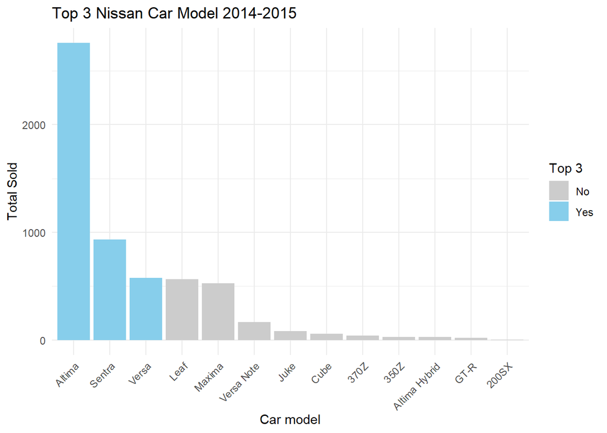

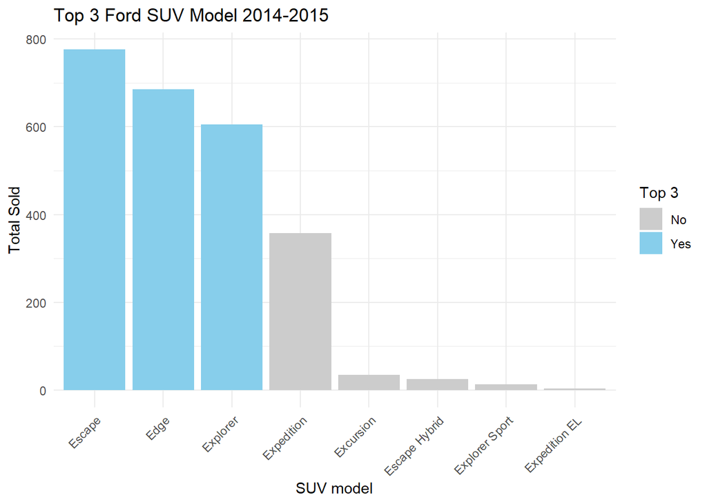

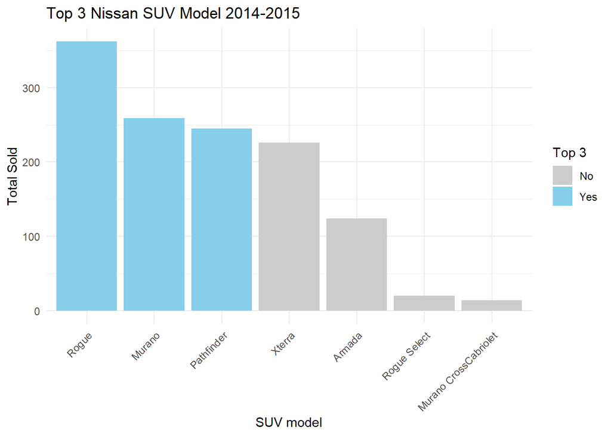

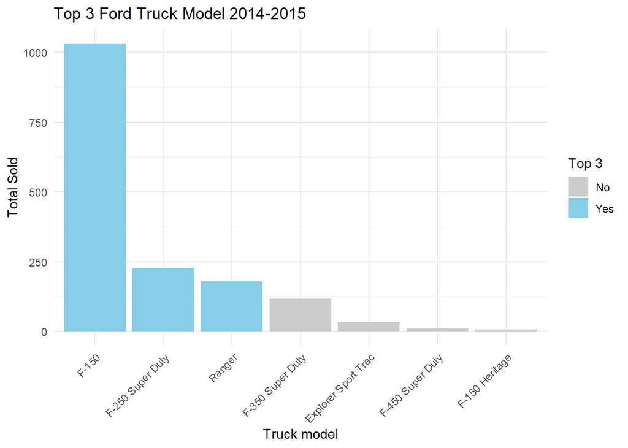

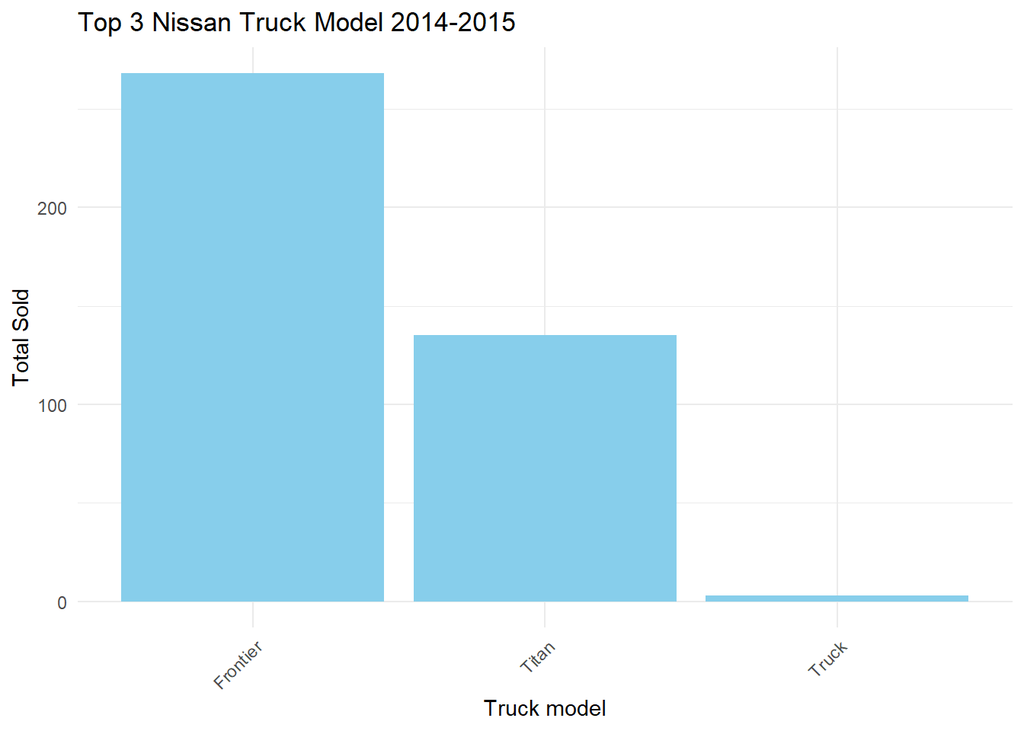

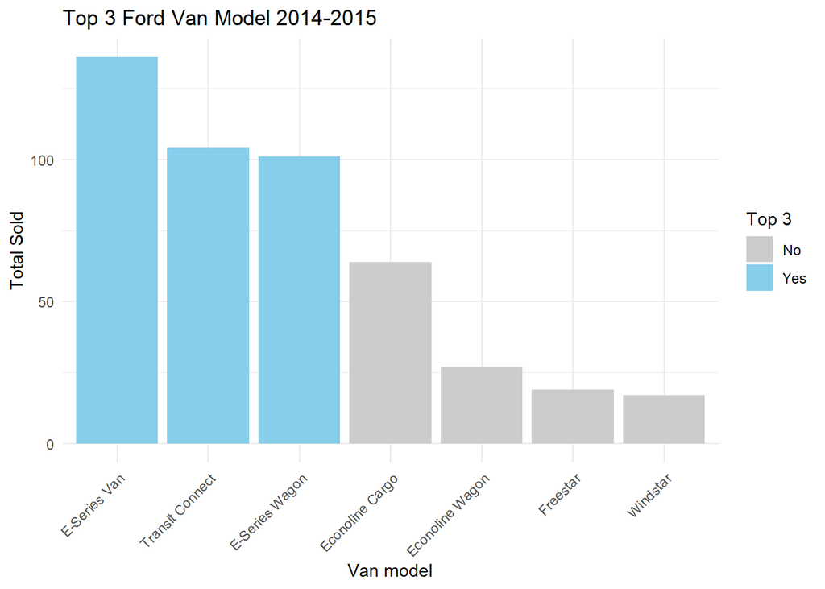

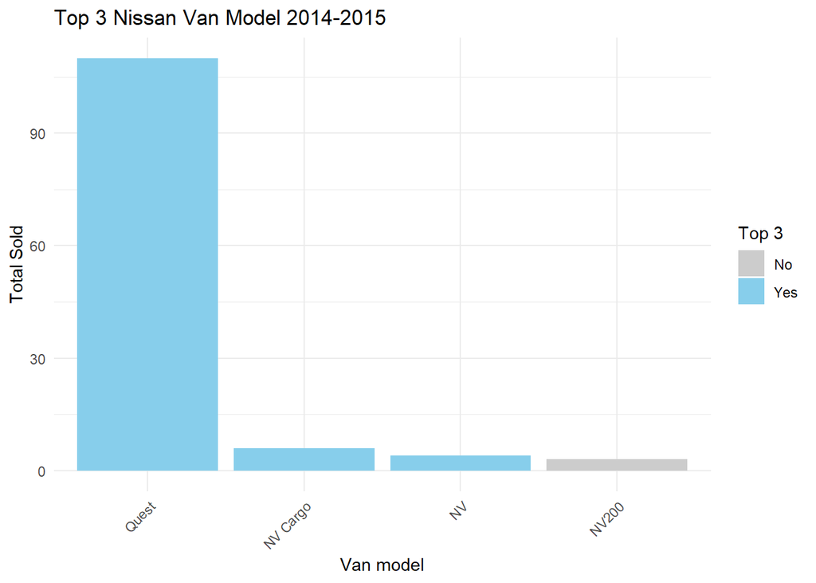

## Limitations/bias of the data

Following ROCCC (Reliable, Original, Comprehensive, Current, Cited) procedures:

Going through each component of ROCCC:

- Reliable: This dataset is provided by a user of Kaggle, its reliability is questionable.
- Original: The provenance stated by the provider of this data was found “online on the internet”, where it was “downloaded from the internet”.
- Comprehensive: The data is comprehensive, containing all critical information needed for the analysis.
- Current: This dataset provide sales record from 2014-2015 so it is not current.
- Cited: This dataset does not cite the original source of the data.

Considering the fact that this dataset does not comply with ROCCC, this data should not be used for analysis in a real-world case involving stakeholders. However, because this data is comprehensive, moving forward I will be making a the setting of this analysis is **hypothetical** taking place as if the data complied with ROCCC where I am an analyst in 2016 given a task by stakeholders at that time.

## Data Description

The source of this [dataset](https://www.kaggle.com/datasets/syedanwarafridi/vehicle-sales-data/data) was accessed from a public third-party source from Kaggle by a user, Syed Anwar. This dataset includes 558,837 records that have 16 variables, or 558,837 rows and 16 columns.

Each record defined through:

- year - year of make
- make - manufacturer of vehicle
- model - model of vehicle
- trim - vehicle model version
- body - type of vehicle
- transmission - type of engine
- vin - vehicle identification number
- state - state within the United States
- condition - condition of the vehicle
- odometer - vehicle mileage
- color - exterior color
- interior - interior color
- seller - the specific dealership
- mmr - Manheim Market Report, leading wholesale value of vehicle
- sellingprice - actual price vehicle was sold
- saledate - date when sale happened

### Licensing, privacy, security and accessiblity

This dataset was released under [MIT](https://www.mit.edu/~amini/LICENSE.md) License. It provides permission (not limited) to use, copy, modify, merge, publish, and distribute.

## Data Wrangling/Prep

During this process I checked for duplicate and missing values, correcting data types, removing outliers, and ensuring uniqueness in each record.

The tools I used to accomplish this task is through PostgreSQL through the DBMS DBeaver.

### Processing process

- Backing up the initial data to archive as a raw data file, I began to do EDA. Before the processing during general exploring I noticed empty strings in the column make and null values from the condition column.
- Removed records that do not include California in the state column.

```sql
delete from car_sales
where state != 'ca'
```

- Checked for duplicates and empty strings in the VIN column, identifying each physical vehicle.

```sql
select
    vin,
    count(*)
from car_sales
group by vin
order by count(*) desc
```

- Multiple VIN counts indicates that the car was resold, no empty strings found.

[figure not shown]

Screenshot from DBeaver

- Removed empty strings in the make column and null values from the condition column.

```sql
delete from car_sales
where make = ''
```

```sql
delete from car_sales
where condition is null
```

- Created new columns to organize saledate into date format and time column and separated Year, Month, Day.

```sql
alter table car_sales
add column dateofsale date,
add column timeofsalepst time,
add column yearofsale varchar(50),
add column monthofsale varchar(50),
add column dayofweek varchar(50)
```

- Two times zones were present (PDT) and (PST), so to keep a consistent format I converted to PDT times to PST time, while updating the columns that were created.

```sql
update car_sales
set
    dateofsale = (
        to_timestamp(substring(saledate , 5, 20), 'Mon DD YYYY HH24:MI:SS')
    ),
    timeofsalepst = (
        case
            when saledate like '%PDT%' then (to_timestamp(substring(saledate , 5, 20), 'Mon DD YYYY HH24:MI:SS') at time zone 'PST' )
            when saledate like '%PST%' then (to_timestamp(substring(saledate , 5, 20), 'Mon DD YYYY HH24:MI:SS') at time zone 'PST' )
        end
    ),
    yearofsale = extract(year from dateofsale),
    monthofsale = substr(saledate, 5, 3),
    dayofweek = substr(saledate, 1, 3)
```

- I realized that I could change the character length of the month and day of week data type from varchar (50) to varchar(3) and varchar(4) for years.
  - The purpose is for better performance and storage efficiency practice.

```sql
alter table car_sales
alter column yearofsale type varchar(4)
alter column monthofsale type varchar(3),
alter column dayofweek type varchar(3)
```

Situation:

- Before exporting the final dataset, I wanted to make sure that it was sorted by earliest sale to oldest sale.
- Problem arose where instead of January being on the top, June was on top, so there was a problem with how the dates were sorted. To address the problem:
  - I added three columns: monos for month of sale, dayos for day of sale, and dayow for day of week.

  ```sql
  alter table car_sales
  add column monos int4,
  add column dayos int4,
  add column dayow int4
  ```

  - Then updated the monos and dayos column using EXTRACT with the corresponding dates from the dateofsale.
  - Since there are no values to EXTRACT for dayofweek I had to map each weekday to a number from 1-7. Additionally to make it more efficient I checked the unique day of the week so that I don’t have to map values to days of the week that did not make sales.

```sql
select distinct dayofweek
from car_sales
```

[figure not shown]

Screenshot from DBeaver

- Sales were made on weekdays, so I map the values 1-5 to each weekday.

```sql
update car_sales
set
    monos = extract(month from dateofsale),
    dayos = extract(day from dateofsale),
    dayow = (
        case
            when dayofweek like 'Mon' then 1
            when dayofweek like 'Tue' then 2
            when dayofweek like 'Wed' then 3
            when dayofweek like 'Thu' then 4
            when dayofweek like 'Fri' then 5
        end)
```

### Exporting

- Sorted the dataset by earliest date before exporting.

```sql
select *
from car_sales
order by yearofsale, monos, dayos
```

- Used the export data feature from DBeaver naming the file ‘car_sales_cleaned.csv’.

### Processing Phase Reflection

- It is important to have some sort of value that can help index dates such that it can be sorted.
- So instead of using just strings to identify the dates I should have added 1-12 for months and 1-7 for days from the start.
- If I had teammates working on the same project I would ask them for their perspective to find any additional processing needed.

## Analysis process

- Loaded packages needed for analysis.

```r
library(readr)
library(ggplot2)
library(dplyr)
library(RColorBrewer)
library(stringr)
library(tidyverse)
```

- Viewed the dataset, there are 70,206 rows and 24 columns.

```r
cars_df <- read.csv("D:/R/car_sales_cleaned.csv")
tibble(cars_df)
```

```
## # A tibble: 70,206 × 24
##     year make      model trim  body  transmission vin   state condition odometer
##    <int> <chr>     <chr> <chr> <chr> <chr>        <chr> <chr>     <int>    <int>
##  1  2012 Nissan    Alti… 2.5 S Sedan automatic    1n4a… ca           19    37887
##  2  2009 Jaguar    XF    Luxu… Sedan automatic    sajw… ca           35    73334
##  3  2004 Porsche   Caye… Turbo SUV   automatic    wp1a… ca           28   114954
##  4  2012 Mercedes… GL-C… GL45… SUV   automatic    4jgb… ca           27    55953
##  5  2013 Ford      Esca… SE    SUV   automatic    1fmc… ca           42    18783
##  6  2013 Ford      Fies… Tita… Hatc… automatic    3fad… ca           42    17391
##  7  2013 Ford      Edge  SE    SUV   automatic    2fmd… ca           45    27239
##  8  2014 Ford      Esca… SE    SUV   automatic    1fmc… ca           43    26035
##  9  2014 Ford      Focus SE    Hatc… automatic    1fad… ca           48    15277
## 10  2014 Ford      Taur… SEL   Sedan automatic    1fah… ca           45    16230
## # ℹ 70,196 more rows
## # ℹ 14 more variables: color <chr>, interior <chr>, seller <chr>, mmr <int>,
## #   sellingprice <int>, saledate <chr>, dateofsale <chr>, timeofsalepst <chr>,
## #   monthofsale <chr>, dayofweek <chr>, monos <int>, dayos <int>, dayow <int>,
## #   yearofsale <int>
```

### Aggregating data

- Created a pivot data frame to summarize the vehicles by manufacturer make.

```r
by_make_cars <- cars_df %>%
  group_by(make) %>%
  summarize(
    total_sold = n(),
    total_sales = sum(sellingprice),
    avg_sell_price = total_sales / total_sold)
tibble(by_make_cars)
```

```
## # A tibble: 81 × 4
##    make         total_sold total_sales avg_sell_price
##    <chr>             <int>       <int>          <dbl>
##  1 Acura               814    11623200         14279.
##  2 Aston Martin         11      660500         60045.
##  3 Audi               1475    34615200         23468.
##  4 BMW                5429   121906871         22455.
##  5 Bentley              66     4921450         74567.
##  6 Buick               327     3071727          9394.
##  7 Cadillac            776    12076851         15563.
##  8 Chevrolet          5867    68229853         11629.
##  9 Chrysler           1488    13919379          9354.
## 10 Dodge              2838    30228881         10651.
## # ℹ 71 more rows
```

- Created a new data frame organized by the most sold make.

```r
most_sold <- arrange(by_make_cars, desc(total_sold))
most_sold$make <- factor(most_sold$make, levels = most_sold$make)
```

- Highlighted the top five most sold makes for data visualization.

```r
most_sold$highlight <- "No"
idx <- order(most_sold$total_sold, decreasing=TRUE)[1:5] #indexing top 5
most_sold$highlight[idx] <- "Yes"
tibble(most_sold)
```

```
## # A tibble: 81 × 5
##    make          total_sold total_sales avg_sell_price highlight
##    <fct>              <int>       <int>          <dbl> <chr>
##  1 Ford                8652   109466182         12652. Yes
##  2 Nissan              7581    85972093         11340. Yes
##  3 Chevrolet           5867    68229853         11629. Yes
##  4 BMW                 5429   121906871         22455. Yes
##  5 Toyota              4514    50401884         11166. Yes
##  6 Mercedes-Benz       4217    98898564         23452. No
##  7 Honda               3679    40212100         10930. No
##  8 Infiniti            3624    75164104         20741. No
##  9 Dodge               2838    30228881         10651. No
## 10 Hyundai             2750    35230653         12811. No
## # ℹ 71 more rows
```

- Created a new data frame for only the top five makes.

```r
top_5 <- cars_df %>%
  filter(make %in% head(most_sold$make, 5)) %>%
  mutate(make = factor(make, levels = c("Ford", "Nissan", "Chevrolet", "BMW", "Toyota"))) %>%
  arrange(make)#ordering by rank
top_5$body <- tolower(top_5$body) # making format consistent
top_5$body <- str_replace(top_5$body, "regular-cab", "regular cab") # making format consistent
tibble(top_5)
```

```
## # A tibble: 32,043 × 24
##     year make  model  trim     body  transmission vin   state condition odometer
##    <int> <fct> <chr>  <chr>    <chr> <chr>        <chr> <chr>     <int>    <int>
##  1  2013 Ford  Escape SE       suv   "automatic"  1fmc… ca           42    18783
##  2  2013 Ford  Fiesta Titanium hatc… "automatic"  3fad… ca           42    17391
##  3  2013 Ford  Edge   SE       suv   "automatic"  2fmd… ca           45    27239
##  4  2014 Ford  Escape SE       suv   "automatic"  1fmc… ca           43    26035
##  5  2014 Ford  Focus  SE       hatc… "automatic"  1fad… ca           48    15277
##  6  2014 Ford  Taurus SEL      sedan "automatic"  1fah… ca           45    16230
##  7  2014 Ford  Escape SE       suv   "automatic"  1fmc… ca           45    29131
##  8  2014 Ford  Focus  SE       hatc… "automatic"  1fad… ca           43    16579
##  9  2013 Ford  Fusion SE       sedan "automatic"  3fa6… ca           46    16158
## 10  2014 Ford  F-150  STX      supe… ""           1fte… ca           44    10843
## # ℹ 32,033 more rows
## # ℹ 14 more variables: color <chr>, interior <chr>, seller <chr>, mmr <int>,
## #   sellingprice <int>, saledate <chr>, dateofsale <chr>, timeofsalepst <chr>,
## #   monthofsale <chr>, dayofweek <chr>, monos <int>, dayos <int>, dayow <int>,
## #   yearofsale <int>
```

- To simplify the analysis process I grouped each body to four categories: Cars, SUVs, Trucks, and Vans.

```r
tibble(unique(top_5$body))
```

```
## # A tibble: 19 × 1
##    `unique(top_5$body)`
##    <chr>
##  1 suv
##  2 hatchback
##  3 sedan
##  4 supercrew
##  5 supercab
##  6 convertible
##  7 van
##  8 crew cab
##  9 e-series van
## 10 minivan
## 11 wagon
## 12 regular cab
## 13 coupe
## 14 extended cab
## 15 king cab
## 16 double cab
## 17 access cab
## 18 crewmax cab
## 19 xtracab
```

- Since there were 19 unique body types for vehicles I utilized AI assistance to make the process more efficient, mapping each body type to the four categories and making a new column that classifies each vehicle.

```r
type_mapping <- c(
  "sedan" = "Car",
  "suv" = "SUV",
  "hatchback" = "Car",
  "supercrew" = "Truck",
  "supercab" = "Truck",
  "van" = "Van",
  "double cab" = "Truck",
  "convertible" = "Car",
  "extended cab" = "Truck",
  "coupe" = "Car",
  "minivan" = "Van",
  "access cab" = "Truck",
  "crew cab" = "Truck",
  "e-series van" = "Van",
  "wagon" = "Car",
  "regular cab" = "Truck",
  "crewmax cab" = "Truck",
  "king cab" = "Truck",
  "xtracab" = "Truck"
)
top_5$vehicle_type <- type_mapping[top_5$body]
tibble(top_5)
```

```
## # A tibble: 32,043 × 25
##     year make  model  trim     body  transmission vin   state condition odometer
##    <int> <fct> <chr>  <chr>    <chr> <chr>        <chr> <chr>     <int>    <int>
##  1  2013 Ford  Escape SE       suv   "automatic"  1fmc… ca           42    18783
##  2  2013 Ford  Fiesta Titanium hatc… "automatic"  3fad… ca           42    17391
##  3  2013 Ford  Edge   SE       suv   "automatic"  2fmd… ca           45    27239
##  4  2014 Ford  Escape SE       suv   "automatic"  1fmc… ca           43    26035
##  5  2014 Ford  Focus  SE       hatc… "automatic"  1fad… ca           48    15277
##  6  2014 Ford  Taurus SEL      sedan "automatic"  1fah… ca           45    16230
##  7  2014 Ford  Escape SE       suv   "automatic"  1fmc… ca           45    29131
##  8  2014 Ford  Focus  SE       hatc… "automatic"  1fad… ca           43    16579
##  9  2013 Ford  Fusion SE       sedan "automatic"  3fa6… ca           46    16158
## 10  2014 Ford  F-150  STX      supe… ""           1fte… ca           44    10843
## # ℹ 32,033 more rows
## # ℹ 15 more variables: color <chr>, interior <chr>, seller <chr>, mmr <int>,
## #   sellingprice <int>, saledate <chr>, dateofsale <chr>, timeofsalepst <chr>,
## #   monthofsale <chr>, dayofweek <chr>, monos <int>, dayos <int>, dayow <int>,
## #   yearofsale <int>, vehicle_type <chr>
```

### Comparative analysis: Ford vs. Nissan

- After grouping each body type I began comparative analysis between Ford and Nissan the top two most sold manufacturer makes.

```r
ford_car <- top_5 %>%
  filter(make == "Ford" & vehicle_type == "Car") %>%
  group_by(model) %>%
  summarize(total_sold = n(),
    total_sales = sum(sellingprice)) %>%
  arrange(desc(total_sold))

nissan_car <- top_5 %>%
  filter(make == "Nissan" & vehicle_type == "Car") %>%
  group_by(model) %>%
  summarize(
    total_sold = n(),
    total_sales = sum(sellingprice)) %>%
  arrange(desc(total_sold))
```

- After creating pivot data frames summarizing Ford and Nissan cars, I highlighted them.

```r
ford_car$model <- factor(ford_car$model, levels = ford_car$model)
nissan_car$model <- factor(nissan_car$model, levels = nissan_car$model)

ford_car$highlight <- "No"
idx <- order(ford_car$total_sold, decreasing=TRUE)[1:3]
ford_car$highlight[idx] <- "Yes"

nissan_car$highlight <- "No"
idx <- order(nissan_car$total_sold, decreasing=TRUE)[1:3]
nissan_car$highlight[idx] <- "Yes"

tibble(ford_car)
```

```
## # A tibble: 20 × 4
##    model             total_sold total_sales highlight
##    <fct>                  <int>       <int> <chr>
##  1 Fusion                  1090    11950901 Yes
##  2 Focus                   1011     8819151 Yes
##  3 Mustang                  873    10388655 Yes
##  4 Taurus                   345     3106926 No
##  5 Fiesta                   332     2985600 No
##  6 Flex                     166     3314450 No
##  7 C-Max Hybrid              48      721200 No
##  8 Five Hundred              45      139900 No
##  9 Fusion Hybrid             44      652050 No
## 10 Freestyle                 24       65950 No
## 11 Thunderbird               20      191450 No
## 12 C-Max Energi              15      248500 No
## 13 Shelby GT500              15      691700 No
## 14 Escort                    12        6150 No
## 15 Fusion Energi             12      274050 No
## 16 Crown Victoria             9       53600 No
## 17 Taurus X                   8       35000 No
## 18 Focus ST                   4       78750 No
## 19 Mustang SVT Cobra          3       17550 No
## 20 Contour                    1        1650 No
```

```r
tibble(nissan_car)
```

```
## # A tibble: 13 × 4
##    model         total_sold total_sales highlight
##    <fct>              <int>       <int> <chr>
##  1 Altima              2760    31659681 Yes
##  2 Sentra               934     8819800 Yes
##  3 Versa                579     4757650 Yes
##  4 Leaf                 566     5685350 No
##  5 Maxima               529     5976907 No
##  6 Versa Note           166     1659000 No
##  7 Juke                  84     1288750 No
##  8 Cube                  58      507650 No
##  9 370Z                  41      863350 No
## 10 350Z                  30      278700 No
## 11 Altima Hybrid         29      232250 No
## 12 GT-R                  22     1685000 No
## 13 200SX                  4        4150 No
```

**I then did the same thing for SUVs, Trucks, and Vans.**

- SUVs

```r
ford_suv <- top_5 %>%
  filter(make == "Ford" & vehicle_type == "SUV") %>%
  group_by(model) %>%
  summarize(
    total_sold = n(),
    total_sales = sum(sellingprice)) %>%
  arrange(desc(total_sold))

nissan_suv <- top_5 %>%
  filter(make == "Nissan" & vehicle_type == "SUV") %>%
  group_by(model) %>%
  summarize(
    total_sold = n(),
    total_sales = sum(sellingprice)) %>%
  arrange(desc(total_sold))
```

```r
ford_suv$model <- factor(ford_suv$model, levels = ford_suv$model)
nissan_suv$model <- factor(nissan_suv$model, levels = nissan_suv$model)

ford_suv$highlight <- "No"
idx <- order(ford_suv$total_sold, decreasing=TRUE)[1:3]
ford_suv$highlight[idx] <- "Yes"

nissan_suv$highlight <- "No"
idx <- order(nissan_suv$total_sold, decreasing=TRUE)[1:3]
nissan_suv$highlight[idx] <- "Yes"
```

- Trucks

```r
ford_truck <- top_5 %>%
  filter(make == "Ford" & vehicle_type == "Truck") %>%
  group_by(model) %>%
  summarize(
    total_sold = n(),
    total_sales = sum(sellingprice)) %>%
  arrange(desc(total_sold))

nissan_truck <- top_5 %>%
  filter(make == "Nissan" & vehicle_type == "Truck") %>%
  group_by(model) %>%
  summarize(
    total_sold = n(),
    total_sales = sum(sellingprice)) %>%
  arrange(desc(total_sold))
```

```r
ford_truck$model <- factor(ford_truck$model, levels = ford_truck$model)
nissan_truck$model <- factor(nissan_truck$model, levels = nissan_truck$model)

ford_truck$highlight <- "No"
idx <- order(ford_truck$total_sold, decreasing=TRUE)[1:3]
ford_truck$highlight[idx] <- "Yes"

nissan_truck$highlight <- "No"
idx <- order(nissan_truck$total_sold, decreasing=TRUE)[1:3]
nissan_truck$highlight[idx] <- "Yes"
```

- Vans

```r
ford_van <- top_5 %>%
  filter(make == "Ford" & vehicle_type == "Van") %>%
  group_by(model) %>%
  summarize(
    total_sold = n(),
    total_sales = sum(sellingprice)) %>%
  arrange(desc(total_sold))

nissan_van <- top_5 %>%
  filter(make == "Nissan" & vehicle_type == "Van") %>%
  group_by(model) %>%
  summarize(
    total_sold = n(),
    total_sales = sum(sellingprice)) %>%
  arrange(desc(total_sold))
```

```r
ford_van$model <- factor(ford_van$model, levels = ford_van$model)
nissan_van$model <- factor(nissan_van$model, levels = nissan_van$model)

ford_van$highlight <- "No"
idx <- order(ford_van$total_sold, decreasing=TRUE)[1:3]
ford_van$highlight[idx] <- "Yes"

nissan_van$highlight <- "No"
idx <- order(nissan_van$total_sold, decreasing=TRUE)[1:3]
nissan_van$highlight[idx] <- "Yes"
```

- All the important aggregated data is now compiled and ready for data visualization.

## Visualization Code

### Aggregate data of top five vehicle makes

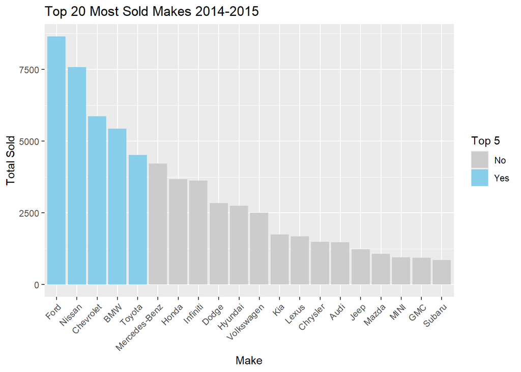

```r
ggplot(data = head(most_sold, 20)) +
  geom_bar(mapping = aes(x = make, y = total_sold, fill = highlight), stat = "identity") +
  labs(title = "Top 20 Most Sold Makes 2014-2015",
       x = "Make",
       y = "Total Sold",
       fill = "Top 5") +
  scale_fill_manual(values = c("gray80", "skyblue")) +
  theme(axis.text.x = element_text(angle = 45, hjust = 1))
```

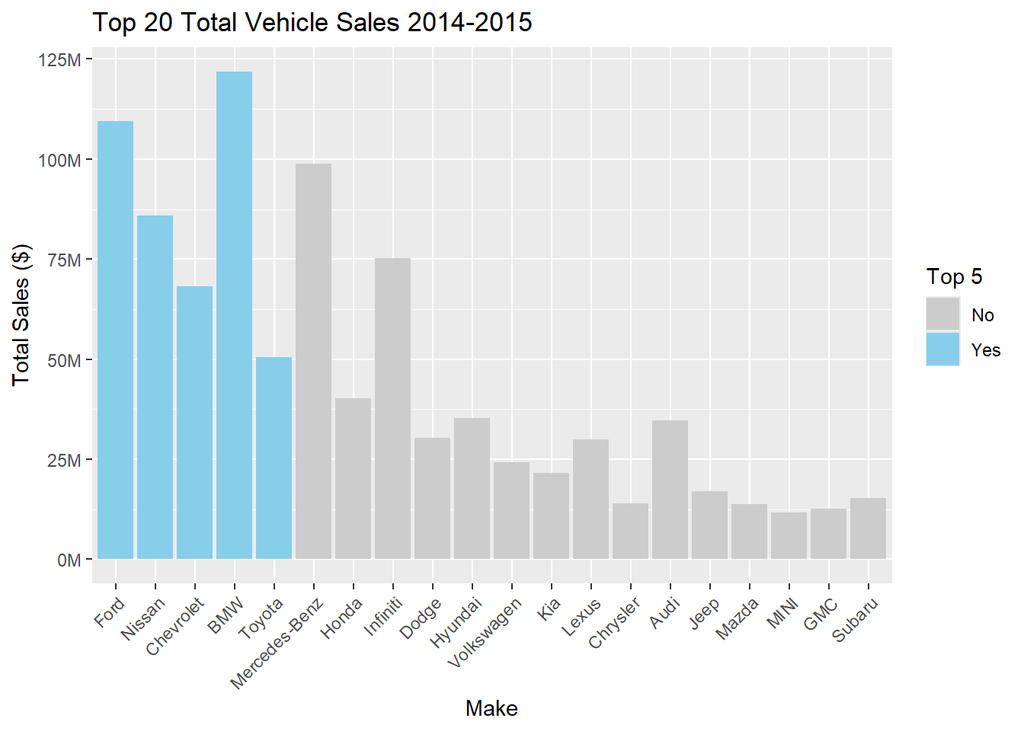

```r
ggplot(data = head(most_sold, 20)) +
  geom_bar(mapping = aes(x = make, y = total_sales, fill = highlight), stat = "identity") +
  scale_y_continuous(labels = scales::label_number(scale = 1e-6, suffix = "M")) +
  labs(title = "Top 20 Total Vehicle Sales 2014-2015",
       x = "Make",
       y = "Total Sales ($)",
       fill = "Top 5") +
  scale_fill_manual(values = c("gray80", "skyblue")) +
  theme(axis.text.x = element_text(angle = 45, hjust = 1))
```

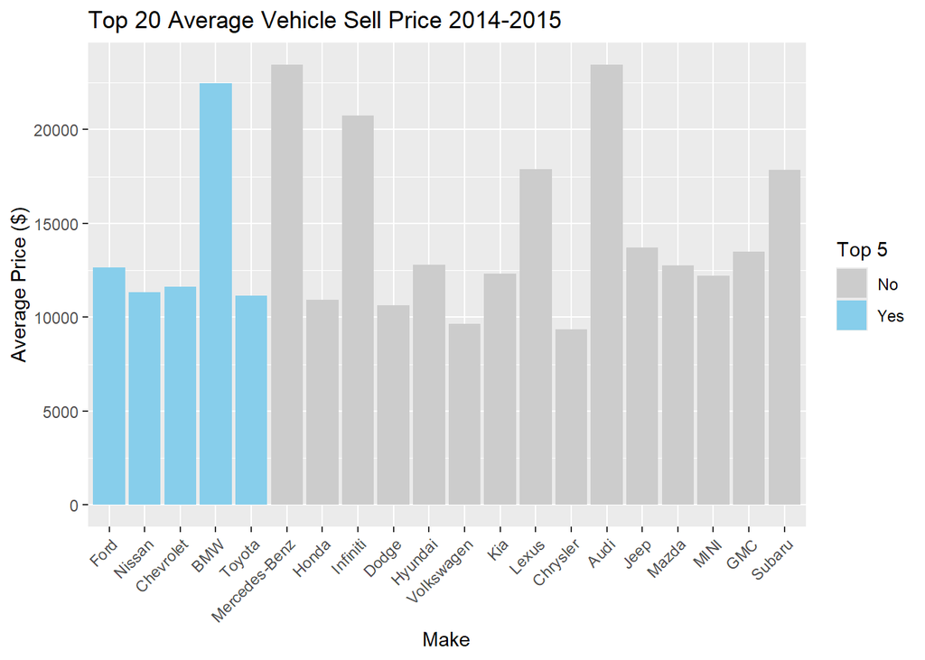

```r
ggplot(data = head(most_sold, 20)) +
  geom_bar(mapping = aes(x = make, y = avg_sell_price, fill = highlight), stat = "identity") +
  labs(title = "Top 20 Average Vehicle Sell Price 2014-2015",
       x = "Make",
       y = "Average Price ($)",
       fill = "Top 5") +
  scale_fill_manual(values = c("gray80", "skyblue")) +
  theme(axis.text.x = element_text(angle = 45, hjust = 1))
```

### Top five makes by vehicle types

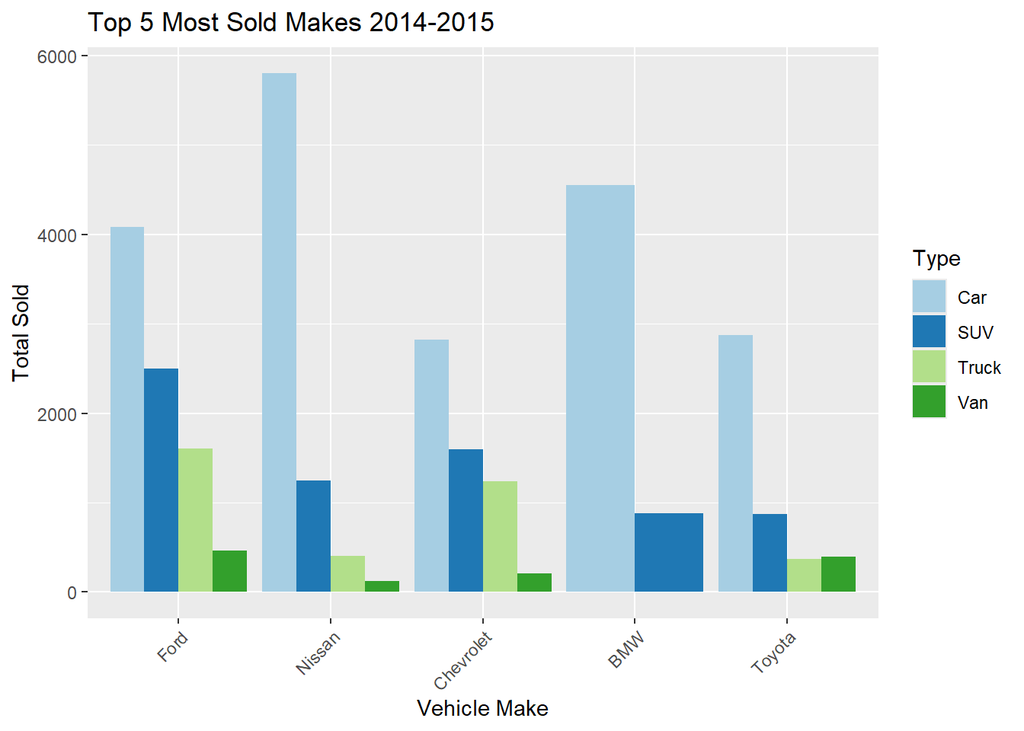

```r
ggplot(data = top_5) +
  geom_bar(mapping = aes(x = make, fill = vehicle_type), stat = "count", position = position_dodge()) +
  labs(title = "Top 5 Most Sold Makes 2014-2015",
       x = "Vehicle Make",
       y = "Total Sold",
       fill = "Type") +
  scale_fill_brewer(palette = "Paired") +
  theme(axis.text.x = element_text(angle = 45, hjust = 1))
```

### Top three Ford & Nissan cars

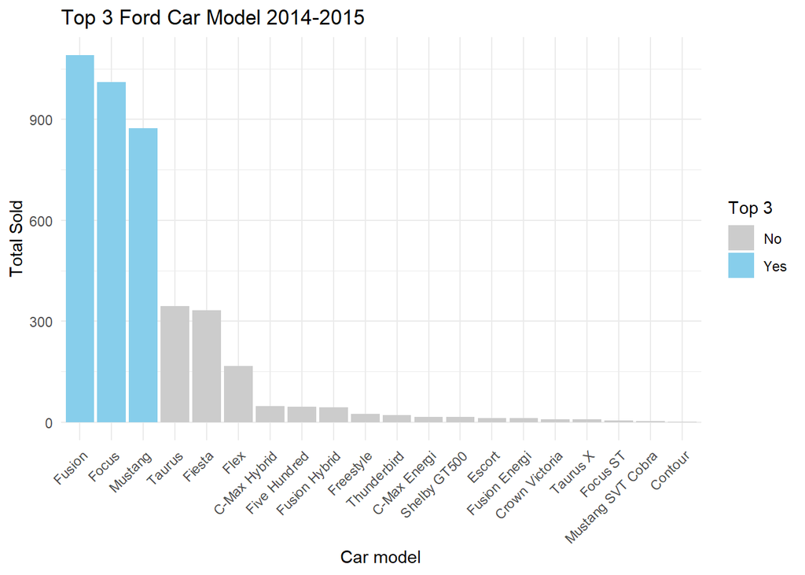

```r
ggplot(data = ford_car) +
  geom_bar(mapping = aes(x=model, y=total_sold, fill = highlight), stat = "identity") +
  labs(title = "Top 3 Ford Car Model 2014-2015",
    x = "Car model",
    y = "Total Sold",
    fill = "Top 3") +
  theme_minimal() +
  theme(axis.text.x = element_text(angle = 45, hjust = 1)) +
  scale_fill_manual(values = c("gray80", "skyblue"))
```

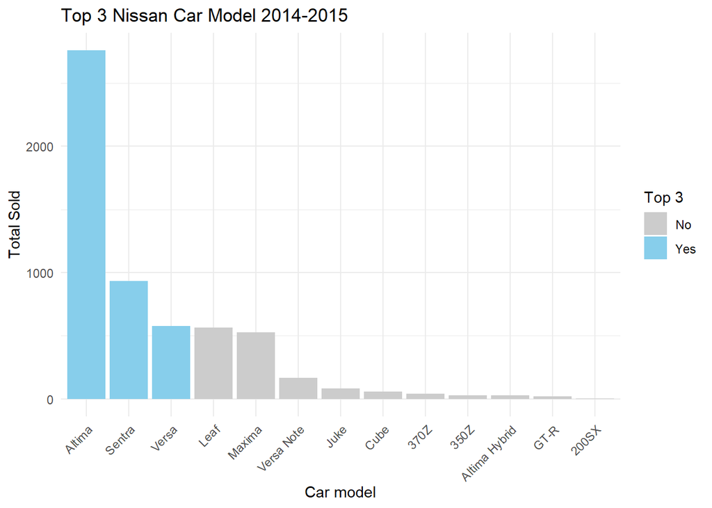

```r
ggplot(data = nissan_car) +
  geom_bar(mapping = aes(x=model, y=total_sold,, fill = highlight), stat = "identity") +
  labs(title = "Top 3 Nissan Car Model 2014-2015",
    x = "Car model",
    y = "Total Sold",
    fill = "Top 3") +
  theme_minimal() +
  theme(axis.text.x = element_text(angle = 45, hjust = 1)) +
  scale_fill_manual(values = c("gray80", "skyblue"))
```

### Top three Ford & Nissan SUVs

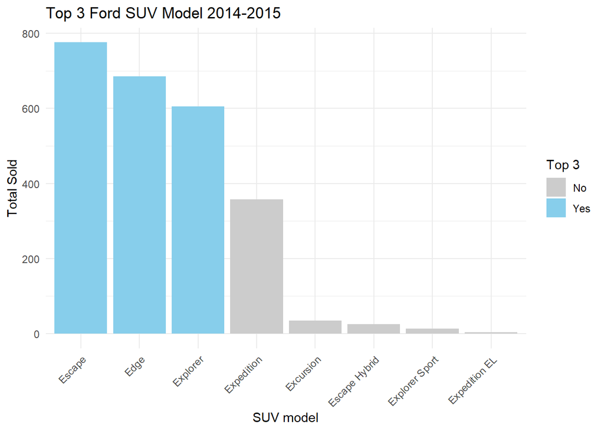

```r
ggplot(data = ford_suv) +
  geom_bar(mapping = aes(x=model, y=total_sold, fill = highlight), stat = "identity") +
  labs(title = "Top 3 Ford SUV Model 2014-2015",
    x = "SUV model",
    y = "Total Sold",
    fill = "Top 3") +
  theme_minimal() +
  theme(axis.text.x = element_text(angle = 45, hjust = 1)) +
  scale_fill_manual(values = c("gray80", "skyblue"))
```

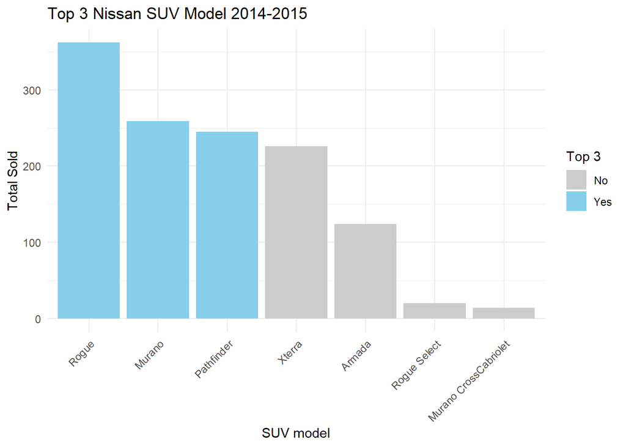

```r
ggplot(data = nissan_suv) +
  geom_bar(mapping = aes(x=model, y=total_sold, fill = highlight), stat = "identity") +
  labs(title = "Top 3 Nissan SUV Model 2014-2015",
    x = "SUV model",
    y = "Total Sold",
    fill = "Top 3") +
  theme_minimal() +
  theme(axis.text.x = element_text(angle = 45, hjust = 1)) +
  scale_fill_manual(values = c("gray80", "skyblue"))
```

### Top three Ford & Nissan trucks

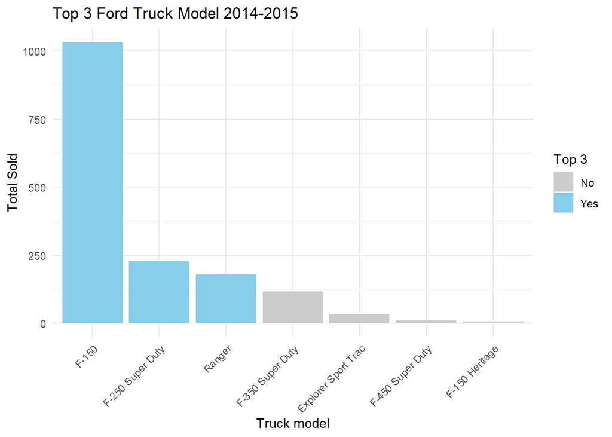

```r
ggplot(data = ford_truck) +
  geom_bar(mapping = aes(x=model, y=total_sold, fill = highlight), stat = "identity") +
  labs(title = "Top 3 Ford Truck Model 2014-2015",
    x = "Truck model",
    y = "Total Sold",
    fill = "Top 3") +
  theme_minimal() +
  theme(axis.text.x = element_text(angle = 45, hjust = 1)) +
  scale_fill_manual(values = c("gray80", "skyblue"))
```

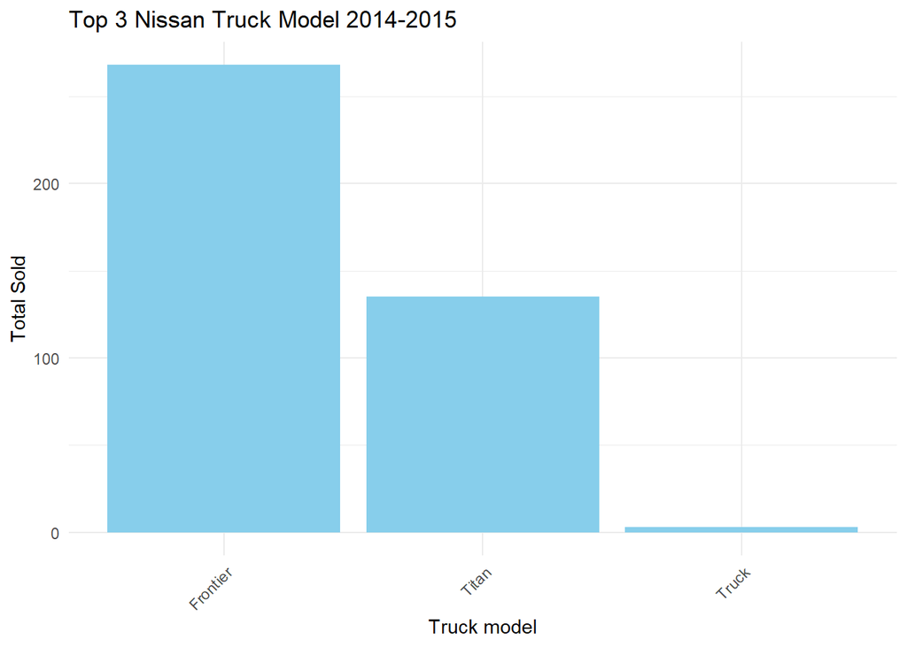

```r
ggplot(data = nissan_truck) +
  geom_bar(mapping = aes(x=model, y=total_sold), stat = "identity", fill = "skyblue") +
  labs(title = "Top 3 Nissan Truck Model 2014-2015",
    x = "Truck model",
    y = "Total Sold") +
  theme_minimal() +
  theme(axis.text.x = element_text(angle = 45, hjust = 1))
```

### Top three Ford & Nissan vans

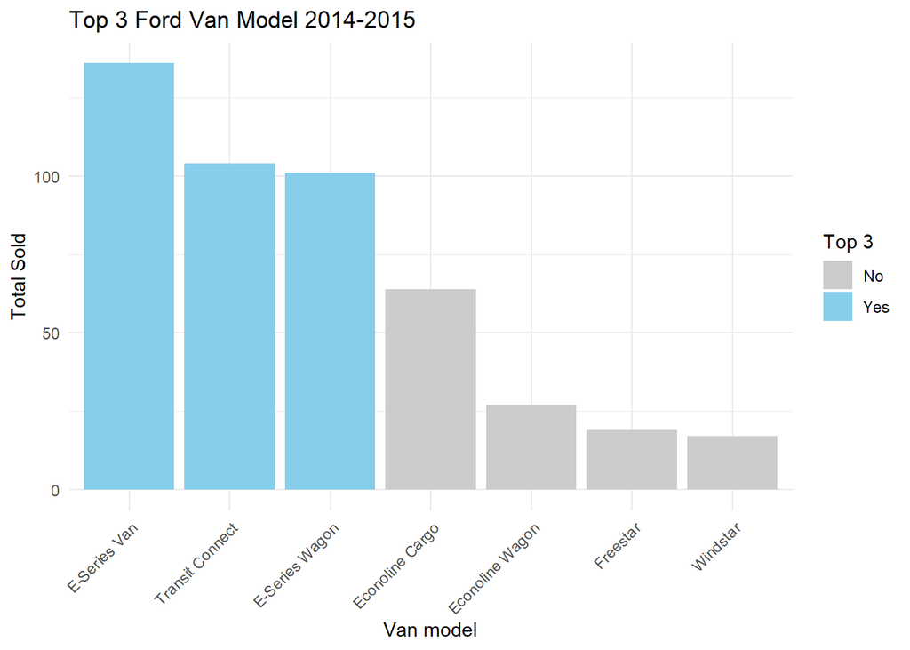

```r
ggplot(data = ford_van) +
  geom_bar(mapping = aes(x=model, y=total_sold, fill = highlight), stat = "identity") +
  labs(title = "Top 3 Ford Van Model 2014-2015",
    x = "Van model",
    y = "Total Sold",
    fill = "Top 3") +
  theme_minimal() +
  theme(axis.text.x = element_text(angle = 45, hjust = 1)) +
  scale_fill_manual(values = c("gray80", "skyblue"))
```

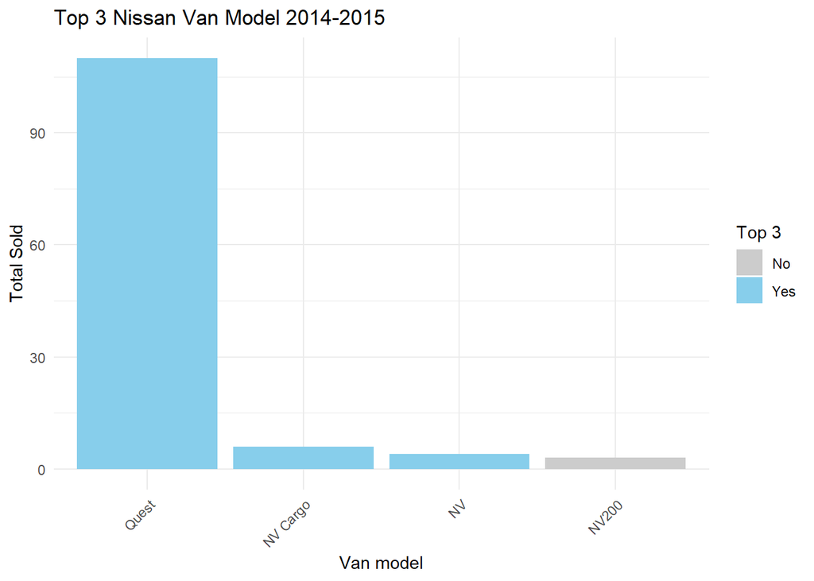

```r
ggplot(data = nissan_van) +
  geom_bar(mapping = aes(x=model, y=total_sold, fill = highlight), stat = "identity") +
  labs(title = "Top 3 Nissan Van Model 2014-2015",
    x = "Van model",
    y = "Total Sold",
    fill = "Top 3") +
  theme_minimal() +
  theme(axis.text.x = element_text(angle = 45, hjust = 1)) +
  scale_fill_manual(values = c("gray80", "skyblue"))
```

## Insights from analysis

Keeping the stakeholder in mind first, the goal of this analysis is to examine car sales data to uncover market characteristics and trends. By pinpointing the most popular vehicle makes, types, and models, we aim to create targeted marketing strategies and guide future vehicle development.

### Top selling vehicle makes

- Ford, Nissan, Chevrolet, BMW, and Toyota are the top five most sold makes, with Ford leading the sales.
- These brands have a lead over others, indicating their strong market presence and consumer preference in California.

### Top Ford Models

- The top three Ford car models are Fusion, Focus, and Mustang.
- For SUVs the top three are Escape, Edge, and Explorer.
- For Trucks the F-150, F250 Super Duty, and Ranger are most popular.
- The top three Ford vans models are the E-Series Van, Transit Connect, and E-Series Wagon.

### Top Nissan Models

- The top three Nissan car models are the Altima, Sentra, and Versa.
- For SUVs the top three are Rogue, Murano, and Pathfinder.
- For Trucks the Frontier and Titan are most popular.
- The top three Nissan vans models are the Quest, NV Cargo, and NV.

## Summary of findings

Given the hypothetical stakeholder case, it is 2016 and I am an analyst for a car dealership company in California.

In this report we analyzed vehicle sales from 2014-2015 to identify market trends and top performing vehicle characteristics. Our key findings:

- Top selling makes: Ford, Nissan, Chevrolet, BMW, and Toyota performed the best in units sold.
- Revenue insights: BMW generated the highest total sales revenue within the top five, indicating a premium pricing strategy
- Vehicle types: Cars and SUVs performed the best among the top five makes.
- Model Popularity: Specific models such as Ford Fusion and Nissan Altima were identified as top sellers in their respective categories.

## Implications

Customer preference is foundation for our marketing and sales strategies. Focus on consumer preferences for certain makes, models, and vehicle types allow us to tailor our inventor and marketing efforts more effectively.

## Future work

Continued analyses could benefit from additional sales records to focus on current sales trends. Additionally, exploring other factors such as regional variations and competitive analysis could enhance the understanding of the market.

## Closing Statement

This vehicle sales analysis has provided critical insights into vehicle sales trends and consumer preferences, promoting our marketing and inventory strategies. By leveraging these insights, we can better meet the needs of out customer enhancing our competitive position.

Thank you to everyone I look forward to implementing these findings to drive our business forward.